# Computation Day 12 - Oscillation Modes

Today we'd like to take a closer look at how to use Python (and either Numpy or Sympy) to find normal frequencies and modes and then visualize those modes in the form of an animation.

### Setup

Suppose you have a situation similar to that which we setup in class last week, with masses spaced between two walls and identical springs ($k=1$) connecting adjacent masses and the edge masses to the walls. In this case though, you have 4 equal masses ($m=1$) instead of the two we had in class (and one more spring connecting to the right wall).

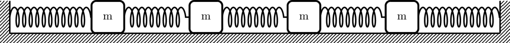

### Part A)

Determine your generalized coordinates and find your equations of motion of each. You can either do this how we did in class with Newton's laws or you can of course still use the Lagrangian. Use your equations of motion to construct the needed $\bf\vec{M}$ and $\bf\vec{K}$ matrices describing the entire system of coupled oscillators.

### Part B)

Find the normal frequencies by solving $\bf{\vec K} - \omega^2\bf{\vec M} = 0$.

### Part C)

For each normal frequency, calculate the corresponding normal mode.

### Part D)

Visualize both the normal frequencies and modes by constructing an animation in which you have four rows of four masses. So each row will correspond to a different mode and the masses in each should move according to corresponding normal frequency and mode. One easy way to do this is to just plot the masses as large points. Give them an initial x position that starts them relatively evenly spaced. No need to solve for any initial constants, just let each object move according to the normal mode times the oscillations at the normal frequency. For example, on Friday we looked at an example with two masses, and found that one of the modes oscillated at a frequency of 1.85 rad/s with a normal mode of [1, -0.414] and the other mode oscillated at a frequency of 0.765 rad/s with a normal mode of [1, 2.414]. If I were to visualize those I'd get something similar to below, so that is the type of animation I'm looking for. In your case though you will have 4 modes.

[video not shown]